# Unit 9 - Model Identification for Stationary Models

# For Live Session

```r
library(tidyverse)
library(tswge)
library(kableExtra)
```

## Question 1

In preparation for the next live session, complete the following. Be sure and submit your work to the “Unit 9:”For Live Session" Assignment" assignment on 2DS:

Please address each activity on at least one PowerPoint slide and submit via the online campus.

Provide as much detail as you need to adequately describe the question of interest. For example

- Provide detail and context, in addition to a number, for questions asking for an estimate.
- You may/should provide code (because your audience is your peers).
- You should provide adequate labels.
- Any other pertinent details to sufficiently convey your response.

Using at least one slide per question

```r
df_texasgasprice = read.csv("./texasgasprice.csv")
# head(df_texasgasprice)

# plotts.sample.wge(df_texasgasprice$Price)

# aic5.wge(df_texasgasprice$Price, type = "aic")
# picks AR(2)

# aic5.wge(df_texasgasprice$Price, type = "bic")
# picks AR(2)

est = est.ar.wge(df_texasgasprice$Price, p=2, type = "mle")
```

```
Coefficients of Original polynomial:
1.3812 -0.4077

Factor                 Roots                Abs Recip    System Freq
1-0.9536B              1.0487               0.9536       0.0000
1-0.4276B              2.3386               0.4276       0.0000



Coefficients of Original polynomial:
1.3812 -0.4077

Factor                 Roots                Abs Recip    System Freq
1-0.9536B              1.0487               0.9536       0.0000
1-0.4276B              2.3386               0.4276       0.0000
```

```r
est
```

```
$phi
[1]  1.3811579 -0.4077432

$res
  [1] -0.0310967793 -0.0630039986 -0.0565786421  0.0171753271  0.0112505642  0.1079432622  0.0410190541  0.0046068868
  [9]  0.0912435510 -0.0432822097 -0.0109961325 -0.0300144940  0.0088142740 -0.0115775325  0.0013122197  0.0741284471
 [17]  0.0256729444  0.0488556669  0.0319550579  0.0257179066  0.0111351474  0.0002560437  0.0504374924  0.0734554439
 [25] -0.0542665512 -0.0106345568  0.0042770318  0.0276557649 -0.0122840927 -0.0443192328 -0.0093813900 -0.0392185046
 [33]  0.0426958180 -0.0605393120 -0.0723691740 -0.0227179698 -0.0270981785 -0.0413735284  0.0102933034  0.0086402925
 [41]  0.0141324393 -0.0525833469 -0.0443666794 -0.0203315613  0.0749376650 -0.0966864146 -0.0409735137 -0.0281995999
 [49]  0.0051067593 -0.0396904664  0.0009022004 -0.0353566800 -0.0182354745 -0.0369493688 -0.0386839484 -0.0428665701
 [57] -0.0286164463 -0.0207678348 -0.0459547732 -0.0081913064  0.0020091440  0.0270829999  0.1065755786 -0.0021351058
 [65]  0.0082534275 -0.0165533023 -0.0499898538  0.0835981651 -0.0362186520  0.0744418416 -0.0379710383 -0.0185095130
 [73]  0.0808532834 -0.0123211713  0.0365582349 -0.0203326683 -0.0337344108  0.0158703866 -0.0400831846 -0.0163227828
 [81] -0.0223291145 -0.0023111849 -0.0387319006 -0.0103253305  0.0108035879  0.0152183030  0.0313590429 -0.0353618012
```

[output cut: 27 more lines]

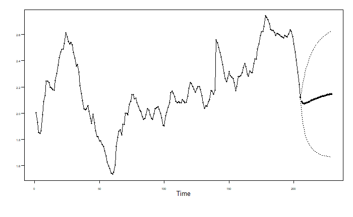

```r
tx_gas_mle_forecast = fore.arma.wge(df_texasgasprice$Price, phi = est$phi, n.ahead = 24, lastn = FALSE, plot = TRUE)
```

```r
kable(head(df_texasgasprice)) %>%
  kable_styling(bootstrap_options = c("striped", "hover", "condensed", "responsive"))
```

| Year | Month | Day | Price |
| --- | --- | --- | --- |
| 2015 | 1 | 5 | 2.004 |
| 2015 | 1 | 12 | 1.932 |
| 2015 | 1 | 19 | 1.853 |
| 2015 | 1 | 26 | 1.847 |
| 2015 | 2 | 2 | 1.865 |
| 2015 | 2 | 9 | 1.989 |

# Asynchronous Material

## 9.1 Introduction

### Introduction and Setting

**Model Free Methods**

- Windowed spectral estimators
- Sample autocorrelations
- Filtering procedures

**Model Dependent Techniques**

- AR models
- Signal-plus-noise models
- ARMA models
- ARIMA models
- Seasonal models

## 9.2 Estimation: Introduction

### Estimation Methods for Stationary Models

`est.arma.wge` - Maximum likelihood estimation only `est.ar.wge` - Maximum likelihood - Yule-Walker - Burger

- For ARMA(p,q) models with q > 0, tswge only produces maximum likelihood estimates.
- For AR(p) models, tswge provides ML, YW. and Burg estimates

## 9.3 Estimation: Maximum Likelihood Estimation

### 9.3.1

- Involves maximizing the likelihood function L = f(x_1, x_2, …, x_n), which is the joint distribution of the time series realization
- Iterative, computationally intensive procedure
- Involves distributional assumptions about white noise (we will assume normal white noise)
- Is applicable to AR(p), MA(q) and ARMA(p,q) models

### 9.3.2 tswge

The key function for ML estimation in an ARMA model is `est.arma.wge`(data, p, q)

Type:

- mle (only)

However, if you know that the model is an AR(p) model, then you can use

`est.ar.wge`(data, p, q, type)

Types:

- mle (default)
- yw
- burg

Final Model Estimation

$$\begin{equation}
(1 - 1.64B + .81B^2)(X_t - 49.96) = (1 - .87B)a_t ; \sigma^2_a = 5.19
\end{equation}$$

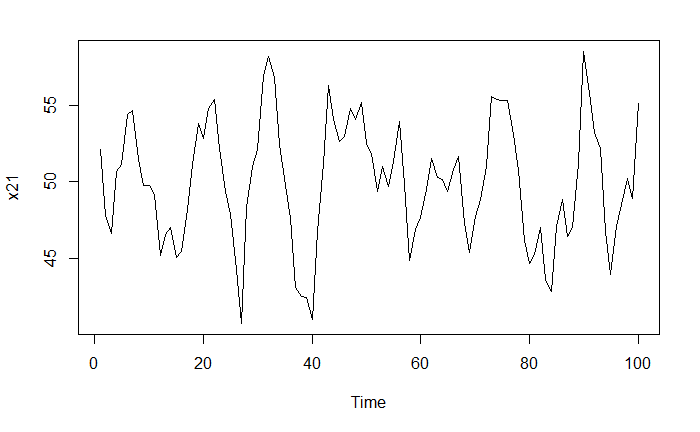

```r
# ARMA(2,1)

# (1 - 1.6B + .8B^2)(X_t - 50) = (1 - .8B)a_t, sigma_squared = 5

x21 = gen.arma.wge(n=100, phi = c(1.6, -.8), theta = .8, vara = 5, sn = 55, plot = FALSE)
x21 = x21 + 50 # gen.arma generates data from a zero mean model.
plot.ts(x21)
```

```r
# We use this strategy to generate the AR(2) model with mean 50.
est.arma.wge(x21, p=2, q=1)
```

```
Coefficients of Original polynomial:
1.6444 -0.8146

Factor                 Roots                Abs Recip    System Freq
1-1.6444B+0.8146B^2
```

[output not shown]

```
    1.0093+-0.4571i      0.9026       0.0677


$phi
[1]  1.6443723 -0.8146435

$theta
[1] 0.8699951

$res
  [1]  0.708663190 -3.576514218 -1.145100236  3.503142882  0.292612485  3.342618746  1.296194246 -1.556399971
  [9] -0.131991017  1.241233628  0.413138981 -3.241646185  0.957903384 -0.393722267 -3.225175124 -1.569317990
 [17]  0.232850678  0.632631404  1.024449020 -1.604768557  1.852149875  1.402910163 -1.500270430 -1.157320811
 [25] -0.304303703 -3.037178596 -4.153065912  5.276967794  0.781898962 -0.189529413  4.141255796  2.074177227
 [33]  0.827133386 -1.386314566  0.592954901 -0.286273269 -3.027579855 -0.715037097 -1.429739309 -3.973286863
 [41]  1.943034697  0.908338767  2.496163031 -3.146205173 -1.639453348  0.495476159  2.522652672  0.775768888
 [49]  3.137425854 -0.002468167  1.925842364  0.103461610  3.632186113  0.664654107  3.293314899  4.325651300
 [57] -1.756220831 -3.242596002  2.448380842  0.747894312  1.430175517  1.716860479 -1.196243212 -0.044054921
 [65] -0.715954414  1.377565647  1.006784995 -3.908704198 -2.224401832  1.259847480 -0.161491913  0.977050389
 [73]  3.807033320  0.365289492  1.352399540  2.095543449  0.572601554  0.451693094 -2.114513566 -0.277348734
 [81]  0.677307212  1.045806571 -4.381676364 -2.952664478  1.113158728 -1.207383824 -5.092014308 -2.530367638
 [89]  1.084571638  5.043761654 -2.901630113 -1.837474906 -0.010328248 -4.182663986 -2.614892946  2.170780089
 [97]  0.258704536  0.486857076 -2.197422400  5.190722918

$avar
[1] 5.186772

$aic
[1] 1.726112

$aicc
[1] 2.752494

$bic
[1] 1.830318

$se.phi
[1] 0.004352046 0.003117565

$se.theta
[1] 0.009271033
```

```r
mean(x21)
```

```
[1] 49.9592
```

Final Model Estimation

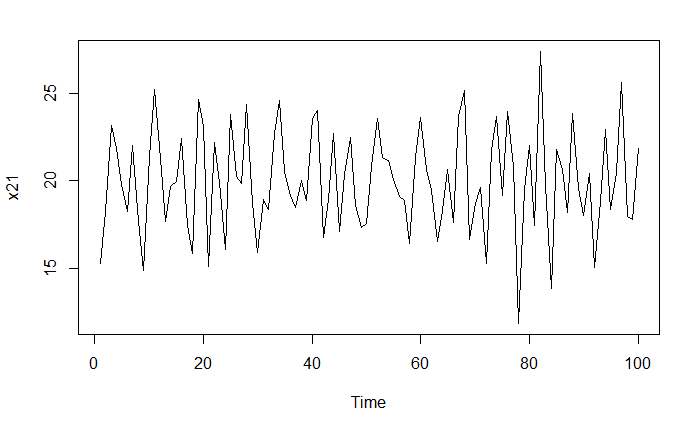

```r
# ARMA(2,1)

# (1 + .7B^2 - .1B^3 + .72B^4)(X_t - 20) = a_t, sigma_squared = 10

x21 = gen.arma.wge(n=100, phi = c(0, -.7, .1, -.72), vara = 4, sn = 72, plot = FALSE)
x21 = x21 + 20 # gen.arma generates data from a zero mean model.
plot.ts(x21)
```

```r
# We use this strategy to generate the AR(2) model with mean 50.
est.arma.wge(x21, p=4, q=1)
```

```
Coefficients of Original polynomial:
0.2529 -0.6715 0.1988 -0.6905

Factor                 Roots                Abs Recip    System Freq
1-1.1297B+0.8366B^2    0.6751+-0.8599i      0.9147       0.1441
1+0.8768B+0.8253B^2   -0.5312+-0.9641i      0.9085       0.3301


$phi
[1]  0.2529169 -0.6714968  0.1987638 -0.6904729

$theta
[1] 0.3842064

$res
  [1] -2.16884807 -1.10802236  0.43068930  1.35914987 -0.92526175 -2.60812205  3.17226246 -1.42317238 -3.49695925
 [10] -1.78960844  2.59220950  1.38551060 -2.41046722  0.17860637  1.90792583  4.33507404 -3.03336994 -3.24200815
 [19]  2.26261849  2.19375881 -2.62171642  0.74455536 -1.01925667  0.34885730  1.07141023 -1.34945831  2.54457648
 [28]  2.14945929  0.93735442 -0.21045722 -1.90062381 -1.52757395  1.81413706  0.94316805  1.21769448  0.93308027
 [37]  0.40395434  3.09412526 -0.37242801  3.47819076  2.69064309 -0.57095011  0.80475781  2.81293642  0.25174753
 [46]  1.00953719 -0.43358583  0.51210600 -2.52332098 -3.88107363  0.14357179  1.35175542  0.17239641  1.44102004
 [55]  1.12152398  2.47834991  0.85067046 -2.80797997  0.67690024  0.77007636  0.89684863 -0.65412883 -2.94460252
 [64]  0.12781086 -0.62477606 -3.57639412  1.29969089  1.87353191 -0.52540237  0.49764335 -0.59755443 -1.47062700
 [73]  0.09343566 -0.69219447 -0.16244033  2.99302316  0.91582357 -2.59348290 -0.23903094 -0.79200826 -1.46521275
 [82]  3.36769134 -3.27676083 -0.41785808 -0.17852859  1.19660071  0.78402143  0.47850236 -1.27008902  1.06215759
 [91] -0.93365782 -3.95183854 -1.02870870 -1.87344907 -2.58557314 -1.24377949  2.54633596  0.26583512  0.97144738
[100]  0.66114222

$avar
[1] 3.435698

$aic
[1] 1.35422

$aicc
[1] 2.386394

$bic
[1] 1.51053

$se.phi
[1] 0.012429907 0.005666667 0.006974917 0.005215893

$se.theta
[1] 0.02940057
```

```r
mean(x21)
```

```
[1] 19.98913
```

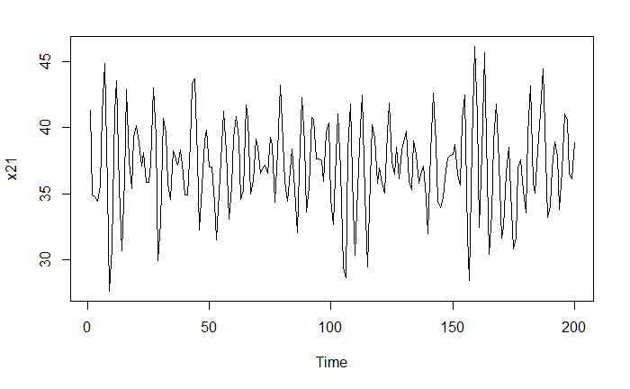

```r
# ARMA(2,1)

# (1 - .3B + .7B^2)(X_t - 37) = (1 + .4B)a_t, sigma_squared = 4

x21 = gen.arma.wge(n=200, phi = c(.3, -.7), theta = -.4, vara = 4, sn = 27, plot = FALSE)
x21 = x21 + 37 # gen.arma generates data from a zero mean model.
plot.ts(x21)
```

```r
# We use this strategy to generate the AR(2) model with mean 50.
est.arma.wge(x21, p=2, q=1)
```

```
Coefficients of Original polynomial:
0.3123 -0.6912

Factor                 Roots                Abs Recip    System Freq
1-0.3123B+0.6912B^2    0.2259+-1.1814i      0.8314       0.2199


$phi
[1]  0.3123135 -0.6911635

$theta
[1] -0.5347094

$res
  [1]  0.29062182 -0.07764962  1.23090109 -4.24562953 -0.06442293  2.46517450  4.13180962 -3.73941416 -1.64578902
 [10] -3.61671221  1.31979367  0.09791037 -0.93998505 -1.05297969  0.38582156  1.34726188 -2.90627148  3.63796454
 [19]  0.91023942  0.62168708  1.84588756  0.44441841  1.88843741 -2.70097064  1.21264232 -1.01926714  5.43778509
 [28] -2.49917439 -2.52211883  0.69908372 -0.48776802 -1.43297432  1.05031041 -1.08403566  1.56240478 -2.34310254
 [37]  1.82615972  0.61550990 -0.60251309 -1.20973402 -0.82179230  1.20086516  3.41182767  3.95516606  0.61054369
 [46] -0.87608704  0.78736379 -1.47532049  1.76219349 -0.65300718  2.09047779 -4.05498408 -2.67597393 -0.93314428
 [55] -1.17546861  2.75241462 -0.65101940 -1.23726389  1.08555053 -0.88264067  2.43199002  0.97368212 -1.17592499
 [64]  0.88655894  2.95291198 -0.81499323  0.34174781  1.74013546 -0.09767721  0.01905511  0.28960163  0.83450542
 [73] -0.83197394 -0.31988751  2.45895237 -0.90132501 -1.37009471  3.66355147  1.82461877  1.00088421  1.38954411
 [82] -0.91610982 -0.78899494  0.15692440 -3.17864360 -1.96147539  0.95327915  1.22669558 -0.91692857 -0.02649951
 [91]  0.61079139  1.37239432  0.49651273  1.62463210  1.89380097 -0.51090239 -0.72106921  3.48294905 -0.26081123
[100] -1.73248650 -0.56849359  0.76113522  0.09482410 -1.07480849 -4.35643492 -4.05191688  0.62135864 -1.92948248
[109] -3.01339207 -0.94988199 -1.45124563 -0.56931129  3.54527074 -3.83303363 -1.30919574  0.49720514 -2.20092151
[118]  1.48306656 -0.67448606  1.96268281 -3.32740853 -0.08517504  2.22186270  1.23072623 -0.11917082  2.51722053
[127]  0.45552477 -2.20870002  3.62995407 -1.31221072  3.55536084 -2.75188822  1.82486675  0.56848072 -1.28918518
[136]  0.34229710  0.15792592 -0.91578344 -2.36652859 -3.21824101  2.57860874  0.17912293  0.47233894  0.26473287
[145] -1.40005936 -2.55601708 -1.06120463 -0.27919549  0.08099241  0.92868826  1.29879088 -1.28285773  0.48200099
[154]  3.20842599  1.50872991 -5.38683756 -0.54007426  0.91214293  1.98457170  0.86880063 -0.08362452  5.00349145
[163]  2.29698555 -1.23318974 -0.86022524  0.33454970 -1.96644835  2.59601411 -1.39960197 -1.68149609 -1.93827434
[172] -1.90116254 -0.70311253 -2.47569768 -3.48893075 -3.07818518 -1.22731491 -2.72446451 -0.70025823 -2.41476659
[181]  3.44988317  0.93213893 -2.04090950  3.55411469 -1.03335345  2.80703393  5.25965052  0.60392222 -0.19243142
[190]  0.27102431 -2.17507230  0.90071378 -0.50314819 -2.07339284  2.25616434  0.50432777  1.69708692  0.03814065
[199]  1.54879606  0.69362005

$avar
[1] 3.943131

$aic
[1] 1.411975

$aicc
[1] 2.423521

$bic
[1] 1.477941

$se.phi
[1] 0.003665979 0.003013635

$se.theta
[1] 0.005904055
```

```r
mean(x21)
```

```
[1] 37.17206
```

## 9.4 Estimation: Yule–Walker Estimates

Change p_k to p_k (hat) and solve the resulting system of equations for phi_1_hat, …, phi_p_hat

These are the Yule-Walker estimates

## 9.5 Estimation: Burg Estimates

In AR models, there is no preference in time direction (recall p_k = p_-k)

Goal is to minimize forward-backward least squares.

Burg showed how to miminize the forward-backward least squares, while at the same time assuring a stationary solution.

### 9.4.4

- Maximum likelihood estimation

*Estimates found by finding the values that provide the largest value of the joint distribution of the time series realization. This is an iterative procedure.*

- Yule–Walker estimation

*Estimates found by solving a system of linear equations by estimating the autocorrelations.*

- Burg estimation

*Estimates found by minimizing the forward backward least squares.*

Match the estimation models to the correct description.

### 9.5.5

Which estimates can estimate parameters from both stationary and nonstationary models?

*Maximum likelihood estimates*

### 9.5.6

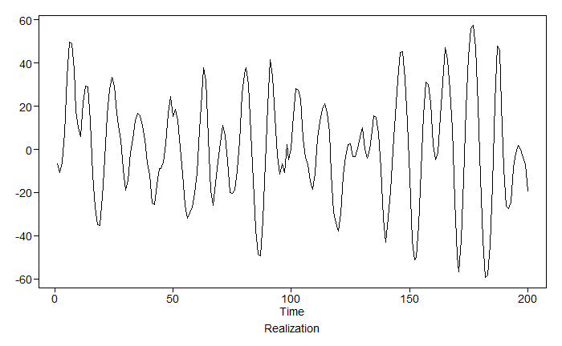

```r
# Generate Data from an AR(2):  (1 - 1.6B + .9B^2)X_t = a_t

x = gen.arma.wge(n = 200, phi = c(1.6, -.9), vara = 37, sn = 33)
```

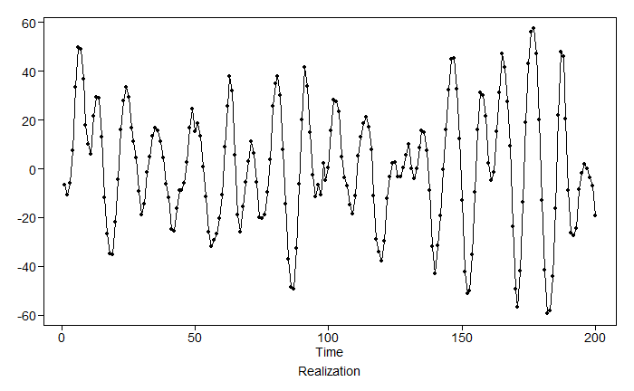

```r
plotts.wge(x)
```

```r
# Yule-Walker Estimates
x.yw = est.ar.wge(x, p=2, type = "yw")
```

```
Coefficients of Original polynomial:
1.5700 -0.8723

Factor                 Roots                Abs Recip    System Freq
1-1.5700B+0.8723B^2    0.8999+-0.5802i      0.9340       0.0911
```

```r
x.yw
```

```
$phi
[1]  1.5699655 -0.8723009

$res
  [1]  -1.41529046  -1.21511695   4.82389435   6.97121963  16.53144238   3.60997250  -0.03000912   2.65612027
  [9]   3.12131348  13.64868621   5.53626949  20.87045637   0.42357170   1.43618917  -6.86741456  -7.26353267
 [17]   2.92984078  -3.60064202  -3.56723653   2.42768700  -0.86647775   3.85380170  -1.60871127   3.47820812
 [25]   1.24073535  -0.59285712  10.44657424   1.15698473  -6.53166419  -0.81527565   6.95301872   4.59894764
 [33]  -5.50782948   3.98116356  -0.01831927   0.73146613   0.92974137   0.58221683  -3.94205346   1.84536427
 [41] -11.97770660   2.70592738   2.09220601  -5.65818295  -9.62533320   0.31528312   3.64589936   7.69286018
 [49]  -0.21040090  -8.30687070  15.30692415  -2.17715565  -4.44293701  -1.48227360  -7.01391631  -1.44713922
 [57]  -2.22251030  -8.47257185  -4.61827920  -1.92027862   7.86450538   1.91450322   5.19200948  -5.39651525
 [65] -11.47998883  -0.39505596   8.61096710   8.48904417  -3.94383489  -2.10291093   1.54205697  -9.06462854
 [73]  -5.65516844  -6.08641311   6.16715872  -4.75261499   2.05041809   2.19694471  11.37257955  -2.36109934
 [81]   5.25634325   0.63609330  -6.11652390  -1.21680418  -7.18775598  -3.52588916  -5.36107321   1.94651520
```

[output cut: 26 more lines]

```r
# Burg Estimates
x.burg = est.ar.wge(x, p=2, type="burg")
```

```
Coefficients of Original polynomial:
1.5846 -0.8862

Factor                 Roots                Abs Recip    System Freq
1-1.5846B+0.8862B^2    0.8940+-0.5737i      0.9414       0.0908
```

```r
x.burg
```

```
$phi
[1]  1.584557 -0.886247

$res
  [1]  -1.278428957  -1.088030873   4.885365130   6.907711525  16.343667845   3.226569304  -0.290269819   2.632745832
  [9]   3.272466023  13.897877034   5.640011514  20.925520277   0.192198160   1.309789156  -6.879080254  -7.051351530
 [17]   3.283348056  -3.374783113  -3.427610952   2.451714835  -1.035723691   3.613632123  -1.906453630   3.297482481
 [25]   1.143534784  -0.557408625  10.612969554   1.226595731  -6.438717624  -0.618630472   7.101472586   4.547654497
 [33]  -5.687993729   3.887561361  -0.143019042   0.673130093   0.936002641   0.639567910  -3.853005273   2.000780672
 [41] -11.893288433   2.903402791   2.122070983  -5.776345828  -9.725155026   0.323181052   3.606537122   7.575370277
 [49]  -0.421926732  -8.426116890  15.422503656  -2.230884930  -4.382869796  -1.306634531  -6.830898342  -1.231343860
 [57]  -2.120066210  -8.487728208  -4.638801698  -1.990047722   7.736485393   1.632838400   4.943220542  -5.590469623
 [65] -11.416318658  -0.033656292   8.968476073   8.603912858  -4.079131280  -2.239585053   1.421186593  -9.186998660
 [73]  -5.588075234  -5.918232764   6.382614659  -4.735931990   2.044024305   2.076154423  11.185058274  -2.685443154
 [81]   5.103765391   0.569849199  -6.023407298  -0.914707563  -6.862246724  -3.190457533  -5.167191320   1.987360970
```

[output cut: 26 more lines]

```r
# Maximum Likelihood Estimates
x.mle = est.ar.wge(x, p=2, type="mle")
```

```
Coefficients of Original polynomial:
1.5807 -0.8807

Factor                 Roots                Abs Recip    System Freq
1-1.5807B+0.8807B^2    0.8974+-0.5746i      0.9385       0.0906



Coefficients of Original polynomial:
1.5807 -0.8807

Factor                 Roots                Abs Recip    System Freq
1-1.5807B+0.8807B^2    0.8974+-0.5746i      0.9385       0.0906
```

```r
x.mle
```

```
$phi
[1]  1.5806684 -0.8807326

$res
  [1]  -1.330019209  -1.136782367   4.882315686   6.944953192  16.405305581   3.316699623  -0.279656856   2.550763588
  [9]   3.144993898  13.766754996   5.581214738  20.893855159   0.244407492   1.305937066  -6.927420690  -7.158510543
 [17]   3.166901915  -3.412676879  -3.415685580   2.509474718  -0.926333047   3.718230821  -1.817893706   3.317769513
 [25]   1.120531274  -0.625574814  10.516869524   1.179078344  -6.482597147  -0.677851388   7.079621509   4.596542849
 [33]  -5.612636751   3.916444112  -0.117553457   0.665890831   0.905369217   0.597371391  -3.895393554   1.952499782
 [41] -11.903198003   2.873204434   2.159877465  -5.697434042  -9.667786202   0.338182736   3.634350245   7.618389880
 [49]  -0.368836979  -8.423533449  15.349104979  -2.243037511  -4.430798168  -1.376552179  -6.880123032  -1.266738287
 [57]  -2.099645859  -8.425457411  -4.579544594  -1.922574007   7.808725957   1.728569630   4.994577177  -5.583714017
 [65] -11.500128257  -0.186013461   8.864156482   8.608701669  -3.995086069  -2.173963268   1.464467621  -9.158697722
 [73]  -5.625152738  -5.973136649   6.336275509  -4.703243881   2.083274679   2.143443893  11.253699189  -2.604263930
 [81]   5.099443608   0.525712833  -6.115441756  -1.047992501  -6.962220910  -3.252391518  -5.151293759   2.064939090
```

[output cut: 26 more lines]

### 9.5.7

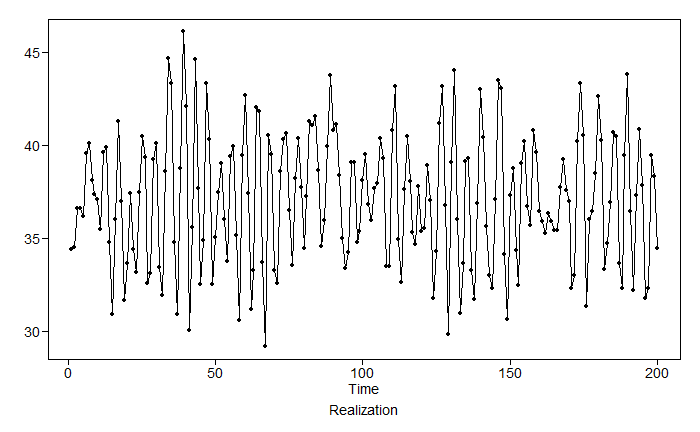

```r
# Generate Data from an AR(2):  (1 - .3B + .7B^2)(X_t - 37) = (1 + .4B)a_t  ; sigma_2 = 4

x = gen.arma.wge(n = 200, phi = c(.3, -.7), theta = -.4, vara = 4, sn = 33, plot = FALSE)
x = x + 37
plotts.wge(x)
```

```r
# Maximum Likelihood Estimates
x.mle= est.arma.wge(x, p=2, q = 1)
```

```
Coefficients of Original polynomial:
0.3040 -0.7379

Factor                 Roots                Abs Recip    System Freq
1-0.3040B+0.7379B^2    0.2060+-1.1457i      0.8590       0.2217
```

```r
x.mle
```

```
$phi
[1]  0.3040351 -0.7379409

$theta
[1] -0.2744466

$res
  [1] -1.24790856 -0.94002509 -1.42157476 -1.86646088 -0.59805750  2.53059395  0.90457532  1.66662046  1.74002358
 [10]  0.20426571 -1.46286929  3.40497026 -0.08799881 -1.27340089 -3.10486984 -0.01117467 -0.08209335 -2.13403537
 [19] -1.72852941 -1.41647528 -2.26810138 -4.74692427 -1.58116828 -0.02292819  0.37959097  1.37930392 -3.06522485
 [28] -0.10520848  0.04292344 -0.59322388 -2.84284007 -1.08554668  0.65059077  3.09510297  4.18714548  0.18833584
 [37] -0.94982068  2.09260456  3.33980760  2.57627783 -2.65025104  5.05757588  1.39689294 -3.19191856  1.67334316
 [46] -0.85043495  3.72919253 -1.35911435 -0.58610792  1.84854290 -2.87038523  1.08356870 -1.69074062 -1.10026517
 [55]  2.79952118 -1.06509775 -0.83317154 -3.59309039  3.89063408 -0.98845805  0.62417595 -2.03604435 -1.23125875
 [64]  2.07290862 -0.16260864 -1.17050676 -3.06210666  4.14158356 -5.59789905 -0.51032782 -1.42556843  0.44392734
 [73] -0.67878013  3.84978076 -0.32775268 -0.68891455  1.96836206 -0.24006670  0.55119582 -0.56324482  1.59072517
 [82]  1.74333085  2.36808350  5.65621758  1.58326353 -0.14637042  0.82364761  1.08411192  4.69039390  2.48824807
 [91]  7.15799943  0.85198072  0.23890165 -2.17855872 -2.67903005  0.85492901 -0.94584234 -1.20037076  0.76556307
[100] -0.39605503  0.94785046 -0.56349058  0.92521533  0.43113820 -0.25903406  3.50683710  0.84656656 -2.08374799
[109] -0.35021084  2.26162349  1.61905646 -1.70925308  1.13491875 -0.01695947 -0.05418005  0.35759607  0.32633700
[118] -1.24222818  0.45024876 -3.86006835  0.52110043  0.87712150 -2.00067372 -3.42838573 -0.26511407  1.05414188
[127]  2.46259078  0.17435975 -2.76697624  4.70569825 -0.33904441 -1.63693379 -0.27453531 -2.31959013 -0.82928252
[136] -0.74295032 -2.82224864 -1.81029300 -0.95357672  2.24919070  0.74708249  1.67026050 -1.67300657 -4.13632248
[145] -0.44255878  3.00593935  3.20600183 -0.93759138 -0.88199741  0.22353226 -3.24769925 -2.19791623 -1.98735128
[154]  1.83214665 -1.40828551  0.45767001  0.86358435  3.58078326 -0.64931997  1.47812058  0.44370853 -2.08872548
[163] -0.50165021 -2.20447510 -1.25182512 -1.73319019  0.40797599  0.60897224  0.10484699  1.32902884 -4.81959760
[172] -1.36889653  1.18468781  1.94468532  3.31253387 -3.12597784  4.04074791 -5.69066751  2.35646065  3.97677797
[181]  1.44192333 -1.06384786  1.43583460 -2.64522001  2.60990144  1.47755869 -2.23484954 -0.62792736  1.44725090
[190]  2.04079324 -1.54034092  0.67399671  0.99704316 -0.17844093 -0.22591450 -2.70623129 -1.86872109  0.41533455
[199] -3.12843694 -0.40861683

$avar
[1] 4.619722

$aic
[1] 1.570335

$aicc
[1] 2.581881

$bic
[1] 1.636301

$se.phi
[1] 0.003313307 0.002388890

$se.theta
[1] 0.006203773
```

### 9.5.8

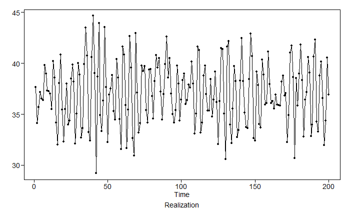

```r
# Generate Data from an AR(2):  (1 - .3B + .7B^2)(X_t - 37) = a_t  ; sigma_2 = 4

x = gen.arma.wge(n = 200, phi = c(.3, -.7), vara = 4, sn = 33, plot = FALSE)
x = x + 37
plotts.wge(x)
```

```r
# Burg Estimates
x.burg = est.ar.wge(x, p=2, type = "burg")
```

```
Coefficients of Original polynomial:
0.2480 -0.7126

Factor                 Roots                Abs Recip    System Freq
1-0.2480B+0.7126B^2    0.1740+-1.1717i      0.8442       0.2265
```

```r
x.burg
```

```
$phi
[1]  0.2479524 -0.7126338

$res
  [1]  0.13107912 -1.49775563 -0.25280854 -1.67783109 -1.56985589 -0.52184186  2.51297959  0.73140614  1.70630164
 [10]  1.47235883  0.05920599 -1.46023041  3.47370152 -0.38515559 -1.07352539 -3.24786460  0.12202556 -0.05940180
 [19] -1.89500419 -1.69125107 -1.53964190 -2.12123765 -4.43994088 -1.29155668 -0.11519513  0.51549953  1.43457566
 [28] -3.24339577  0.01829364 -0.12563769 -0.33476941 -2.78083209 -1.05810455  0.55409003  3.24288596  4.10229452
 [37] -0.16786691 -1.14351795  1.97653157  3.35097219  2.59210518 -2.95093318  4.96413455  0.87015031 -2.71872580
 [46]  1.70413494 -1.36864422  4.01101108 -1.55914749 -0.33667167  1.46207740 -2.97113196  1.53428858 -1.93184544
 [55] -0.92475087  2.68545018 -1.18186630 -0.57431248 -3.79685740  4.08373906 -1.28017251  1.09624184 -2.45086720
 [64] -1.17228649  2.11588457 -0.09017497 -1.06237839 -3.29307101  4.23804523 -5.78791667  0.29399871 -1.98285730
 [73]  0.66638741 -0.64789655  4.04236216 -0.79530025 -0.60622441  1.81339068 -0.29524360  0.73498096 -0.77577451
 [82]  1.55922355  1.60824473  2.40960609  5.43758115  1.08534612 -0.19563303  0.65783307  1.02479058  4.74183551
 [91]  2.15804788  6.99366982  0.12844468  0.36881449 -2.43554433 -2.48115033  1.02321343 -0.95973834 -1.03800305
```

[output cut: 24 more lines]

## 9.6 Estimation: When It Makes a Difference

### 9.6.1

When the real roots are close to the unit circle, the Yule-Walker method does not perform well.

### 9.6.2

Models should not be used when roots are found to be inside the unit circle, this would indicate a non-stationary model.

Burg and Yule-Walker methods will always produce a stationary model.

### 9.6.3

Which of the following statements is `FALSE`?

*Burg estimates may find a nonstationary model (produce roots inside the unit circle).*

## 9.7 Estimation: Noise Variance

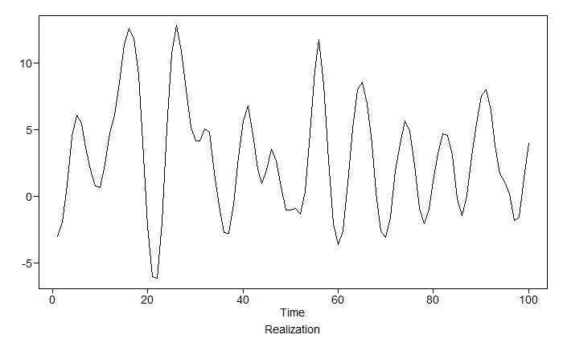

```r
# Generate Data from an AR(2):  (1 - .3B + .7B^2)(X_t - 37) = a_t  ; sigma_2 = 4

x = gen.arma.wge(n = 100, phi = c(2.195, -1.994, .696), vara = 1, sn = 53, plot = TRUE)
```

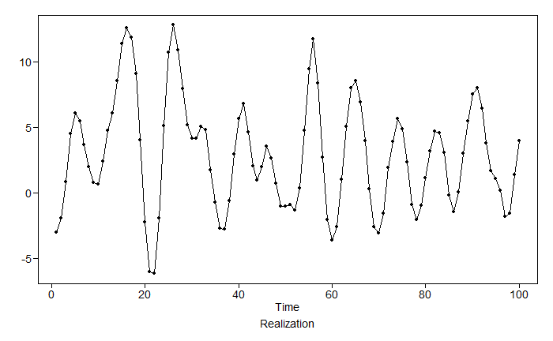

```r
plotts.wge(x)
```

```r
x.mle = est.ar.wge(x, p=3, type = "mle")
```

```
Coefficients of Original polynomial:
1.9823 -1.6458 0.4799

Factor                 Roots                Abs Recip    System Freq
1-1.4105B+0.8392B^2    0.8404+-0.6967i      0.9161       0.1102
1-0.5718B              1.7488               0.5718       0.0000



Coefficients of Original polynomial:
1.9823 -1.6458 0.4799

Factor                 Roots                Abs Recip    System Freq
1-1.4105B+0.8392B^2    0.8404+-0.6967i      0.9161       0.1102
1-0.5718B              1.7488               0.5718       0.0000
```

```r
x.mle$avar
```

```
[1] 0.8079188
```

```r
mean(x.mle$res^2)
```

```
[1] 0.8079188
```

## 9.8 Model Identification: Introduction

Lesson: Always plot the data.

- Check for white noise in the time series plot and via the ACF.

### 9.8.3

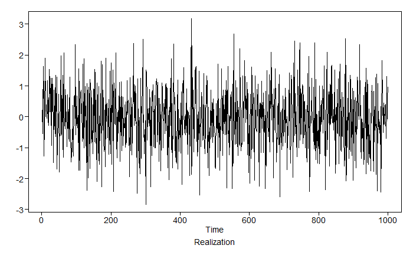

```r
df_white_noise = read.csv("./maybewhitenoise1.csv")
# head(df_white_noise)
plotts.wge(df_white_noise$x)
```

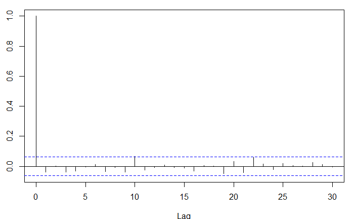

```r
acf(df_white_noise$x)
```

### 9.8.4

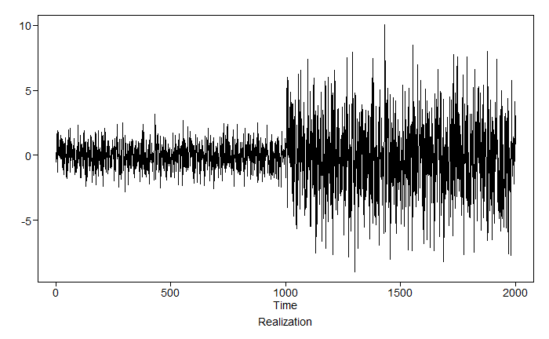

```r
df_white_noise = read.csv("./maybewhitenoise2.csv")
# head(df_white_noise)
plotts.wge(df_white_noise$x)
```

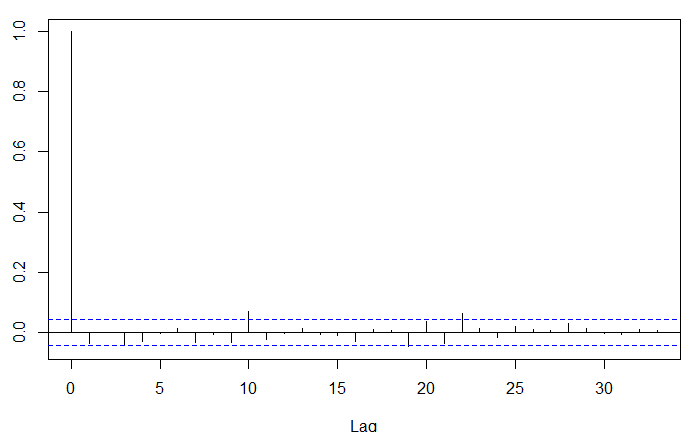

```r
acf(df_white_noise$x)
```

## 9.9 Model Identification: AIC Type, Part I

### 9.9.1

- Method 1 (AIC)
- Method 2 (Box-Jenkins)

Akaike’s Information Criterion (AIC)

A general criterion for statistical model identification you have seen before in other settings.

AIC is actually one of a number of information-based criterion.

AICC BIC Others

### 9.9.2

Adding variables to an existing equation will always reduce the residual/ unexplained variability

In ARMA modeling, the unexplained variability is measured by sigma squared (a)

### 9.9.3 AIC in ARMA modeling

AIC: imposes a penalty for adding terms

$$\begin{equation}
AIC = ln(\hat\sigma^2_a) + 2(p + q + 1) / n
\end{equation}$$

- AIC has a tendency to select a higher-order model as the realization length increases.
- BIC imposes a stronger penalty for increasing p and q.
  - It tends to pick models with fewer parameters.
  - It avoids the problem of “over-modeling” large data sets.
- AICC has a penatly between that for AIC and BIC
- AIC and its variations are for selecting a stationary ARMA model.

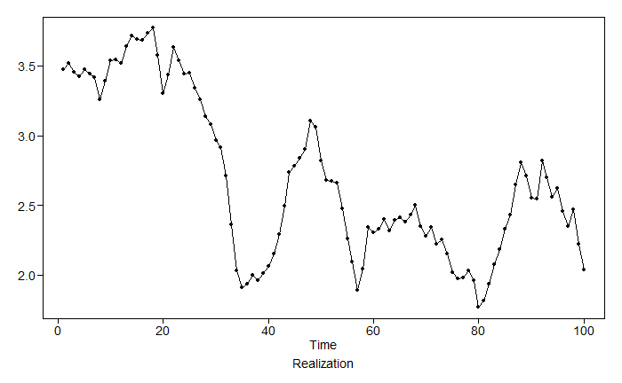

```r
# Generate Data from an ARMA(1,1):  (1 - .967B)(X_t - 2.20) = (1 + .477B)a_t  ; sigma_2 = .0139

# Answer -4.20

x = gen.arma.wge(n = 100, phi = c(.967), theta = -.477, vara = .0139, sn = 53, plot = FALSE)
x = x + 2.20
plotts.wge(x)
```

```r
x.mle = est.arma.wge(x, p=1, q=1)
```

```
Coefficients of Original polynomial:
0.9519

Factor                 Roots                Abs Recip    System Freq
1-0.9519B              1.0505               0.9519       0.0000
```

```r
x.mle$avar
```

```
[1] 0.01321466
```

```r
# mean(x.mle$res^2)

aic.wge(x, p=1, q=1, type = "aic")
```

```
$type
[1] "aic"

$value
[1] -4.266428

$p
[1] 1

$q
[1] 1

$phi
[1] 0.9519497

$theta
[1] -0.6084638

$vara
[1] 0.01321466
```

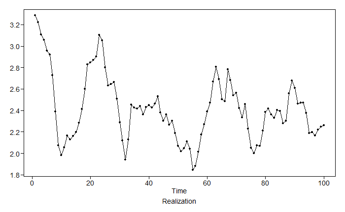

```r
# Generate Data from an ARMA(3, 0):  (1 - .1.45B + .734B^2 - .261B^3)(X_t - 2.20) = a_t  ; sigma_2 = .0137

# Answer -4.19


x = gen.arma.wge(n = 100, phi = c(1.45, -.734, .261), vara = .0137, sn = 53, plot = FALSE)
x = x + 2.20
plotts.wge(x)
```

```r
x.mle = est.arma.wge(x, p=3, q=0)
```

```
Coefficients of Original polynomial:
1.4444 -0.7229 0.1866

Factor                 Roots                Abs Recip    System Freq
1-0.8536B              1.1715               0.8536       0.0000
1-0.5908B+0.2186B^2    1.3514+-1.6579i      0.4675       0.1412
```

```r
x.mle$avar
```

```
[1] 0.01145573
```

```r
# mean(x.mle$res^2)

aic.wge(x, p=3, q=0, type = "aic")
```

```
$type
[1] "aic"

$value
[1] -4.389265

$p
[1] 3

$q
[1] 0

$phi
[1]  1.4443741 -0.7228673  0.1865805

$theta
[1] 0

$vara
[1] 0.01145573
```

## 9.10 Model Identification: AIC Type, Part II

### 9.10.1 AIC in tswge

`aic.wge(x, p=0:5, q=0:2, type = "aic")`

### 9.10.2 AIC demo

```
$autplt
 [1] 1.0000000 0.9744866 0.9063517 0.8145706 0.7216906 0.6467902 0.6004741 0.5833120 0.5874757 0.6006555 0.6107689
[12] 0.6094078 0.5929586 0.5625205 0.5225345 0.4792330 0.4388053 0.4063386 0.3845863 0.3736197 0.3712480 0.3733620
[23] 0.3755428 0.3744032 0.3680972 0.3559616

$freq
  [1] 0.005 0.010 0.015 0.020 0.025 0.030 0.035 0.040 0.045 0.050 0.055 0.060 0.065 0.070 0.075 0.080 0.085 0.090
 [19] 0.095 0.100 0.105 0.110 0.115 0.120 0.125 0.130 0.135 0.140 0.145 0.150 0.155 0.160 0.165 0.170 0.175 0.180
 [37] 0.185 0.190 0.195 0.200 0.205 0.210 0.215 0.220 0.225 0.230 0.235 0.240 0.245 0.250 0.255 0.260 0.265 0.270
 [55] 0.275 0.280 0.285 0.290 0.295 0.300 0.305 0.310 0.315 0.320 0.325 0.330 0.335 0.340 0.345 0.350 0.355 0.360
 [73] 0.365 0.370 0.375 0.380 0.385 0.390 0.395 0.400 0.405 0.410 0.415 0.420 0.425 0.430 0.435 0.440 0.445 0.450
 [91] 0.455 0.460 0.465 0.470 0.475 0.480 0.485 0.490 0.495 0.500

$db
  [1]  16.8397334  12.9761219   4.8853645   4.3805170   1.7180094   1.5500922   4.9135289   5.6565474  -5.4096567
```

[output cut: 25 more lines]

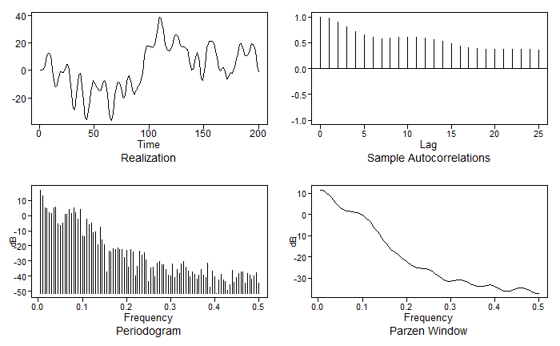

```r
# Generate Data from an AR(3):  (1 - 2.555B + .2.42B^2 - .855B^3) = a_t  ; sigma_2 = 1
# factored form (1 - .95B)(1 - 1.6B + .9B^2)X_t =- a_t

# AIC Demo: aic.wge
# fig3.16a is a realization from the AR(3) model

data("fig3.16a")
# plotts.sample.wge provides a "look" at the data (which we always recommend)
plotts.sample.wge(fig3.16a)
```

```r
# let tswge find the model with the lowest aic
aic.wge(fig3.16a, p=0:5, q=0:2, type="aic")
```

```
$type
[1] "aic"

$value
[1] 0.07040062

$p
[1] 3

$q
[1] 0

$phi
[1]  2.5245680 -2.3447622  0.8104239

$theta
[1] 0

$vara
[1] 1.030867
```

```r
mean(fig3.16a)
```

```
[1] 1.572201
```

```
$autplt
 [1]  1.000000000  0.770340236  0.348479232 -0.153068658 -0.551267572 -0.725616017 -0.644112813 -0.377121642
 [9] -0.056291940  0.233473024  0.392702795  0.398719229  0.315143718  0.161006599  0.004356141 -0.128499078
[17] -0.219178894 -0.250393863 -0.203618310 -0.089779343  0.038681977  0.145946133  0.197022711  0.155126007
[25]  0.076892771 -0.038396982

$freq
 [1] 0.01 0.02 0.03 0.04 0.05 0.06 0.07 0.08 0.09 0.10 0.11 0.12 0.13 0.14 0.15 0.16 0.17 0.18 0.19 0.20 0.21 0.22
[23] 0.23 0.24 0.25 0.26 0.27 0.28 0.29 0.30 0.31 0.32 0.33 0.34 0.35 0.36 0.37 0.38 0.39 0.40 0.41 0.42 0.43 0.44
[45] 0.45 0.46 0.47 0.48 0.49 0.50

$db
 [1]  -7.3559914 -24.4232650 -13.7954113  -5.1993045 -10.2596507   0.6260543   7.6334092   8.9013262  11.5880972
[10]   9.1949613   3.8361230   4.5492493   5.1405469  -4.2235941  -2.9452622 -16.2444334 -15.2603843 -12.2128748
[19] -17.7850707  -5.4339228  -9.8786115  -7.6913144 -18.1540067 -10.3679148 -10.0354575 -14.2069869 -14.7879255
[28]  -9.3481938 -10.4646356 -20.7386295 -12.7725413  -5.5497883 -16.4978078 -12.5254200 -16.8339306 -12.6807134
[37] -14.9778350 -13.0303514 -34.9166740 -11.0366446 -10.0705069 -11.6511406  -8.3567491 -22.3001965  -9.1448452
[46] -16.4401098 -12.5722030 -10.9677443 -10.6368525 -31.0849665

$dbz
 [1]  -4.2634107  -2.4181820  -0.1458218   2.0610822   3.9664800   5.4816191   6.5813963   7.2644549   7.5370706
[10]   7.4074922   6.8848385   5.9803617   4.7104937   3.1017591   1.1979463  -0.9295402  -3.1658787  -5.3312500
[19]  -7.1797517  -8.4975267  -9.2848426  -9.7615227 -10.1545553 -10.5530073 -10.9137908 -11.1443026 -11.1969814
[28] -11.1062771 -10.9534624 -10.8225671 -10.7853946 -10.8989485 -11.1953653 -11.6612744 -12.2125325 -12.6856061
[37] -12.8948717 -12.7641639 -12.3928389 -11.9621961 -11.6182258 -11.4346250 -11.4230784 -11.5487257 -11.7439089
[46] -11.9295894 -12.0479548 -12.0886823 -12.0841868 -12.0765748
```

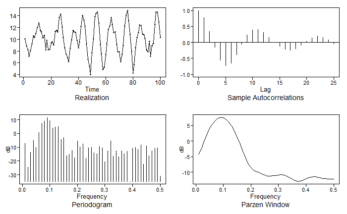

```r
# Generate data from the AR(2,1)

x = gen.arma.wge(n=100, phi=c(1.6, -.9), theta=.8, sn=67, plot = FALSE)
x = x+10

plotts.sample.wge(x)
```

```r
# no types listed below so it will use aic
aic.wge(x, p=0:8, q=0:4)
```

```
$type
[1] "aic"

$value
[1] 0.1534323

$p
[1] 2

$q
[1] 1

$phi
[1]  1.6194830 -0.9131788

$theta
[1] 0.868127

$vara
[1] 1.076196
```

```r
# picks ARMA(2,1)
est.arma.wge(x, p=2, q=1)
```

```
Coefficients of Original polynomial:
1.6195 -0.9132

Factor                 Roots                Abs Recip    System Freq
1-1.6195B+0.9132B^2    0.8867+-0.5557i      0.9556       0.0891


$phi
[1]  1.6194830 -0.9131788

$theta
[1] 0.868127

$res
  [1]  0.021007950 -0.127206788 -0.007065670 -1.052548925  0.216137511 -0.144058549 -0.117571404 -1.364024459
  [9] -0.263879446  0.428198107  0.809542486 -0.501707987  0.894997140  0.349361991  1.669246889 -1.159535551
 [17]  2.214168533 -1.199224616 -0.013306071  0.417338523 -0.633697059 -1.301984619  1.201386244 -0.427285140
 [25] -0.392870180  2.660838937  1.782945490  0.010453275  0.808990797  0.651101636  0.623733562  0.214067391
 [33] -0.910558259  0.914046883 -0.313182877  0.038926208 -1.328017071 -0.680145494 -1.499126304 -1.435248572
 [41]  0.502618672  1.935149155  1.756547506  0.257137179  0.875325416 -0.736142288 -0.782889090 -0.434302976
 [49] -2.078042459  1.353419340 -0.477871723  1.182502382 -0.840538062  0.382956598 -0.440811061 -1.593903925
 [57]  0.103640406 -1.887505175 -0.337432391  0.084519328 -0.830417403 -0.240569399 -1.353928774  0.356344419
 [65] -1.140048277 -0.506183724  1.185296262 -0.796576984 -0.317977160  0.197536142 -2.085443047 -0.222117120
 [73] -0.554834286  1.075423271  0.477419636  0.633435553 -0.420481637 -0.311680014 -0.708236809 -2.338469290
 [81]  1.070839449  1.174761009 -0.200019423 -0.958446246 -0.007828143 -0.552206972 -1.118417548  0.338666409
 [89]  0.127348965 -1.289179492 -0.295811963  1.238879821 -3.152539069  0.356989230 -1.159829984  1.621870082
 [97]  1.276917896  0.456528537  0.121400222 -0.168859333

$avar
[1] 1.076196

$aic
[1] 0.1534323

$aicc
[1] 1.179815

$bic
[1] 0.2576391

$se.phi
[1] 0.001531631 0.001444913

$se.theta
[1] 0.002965317
```

```r
mean(x)
```

```
[1] 10.07557
```

### 9.10.4

tswge and AIC5/ Top 5 Models

```
$autplt
 [1]  1.000000000  0.916461433  0.706850813  0.430784642  0.148942248 -0.098526881 -0.294157633 -0.434336228
 [9] -0.522223884 -0.559457618 -0.543010356 -0.475103780 -0.367123485 -0.235447156 -0.099450664  0.021926546
[17]  0.114525084  0.171457995  0.191851911  0.183782104  0.160100357  0.131267008  0.101864064  0.070405731
[25]  0.037727566  0.009937452

$freq
 [1] 0.01333333 0.02666667 0.04000000 0.05333333 0.06666667 0.08000000 0.09333333 0.10666667 0.12000000 0.13333333
[11] 0.14666667 0.16000000 0.17333333 0.18666667 0.20000000 0.21333333 0.22666667 0.24000000 0.25333333 0.26666667
[21] 0.28000000 0.29333333 0.30666667 0.32000000 0.33333333 0.34666667 0.36000000 0.37333333 0.38666667 0.40000000
[31] 0.41333333 0.42666667 0.44000000 0.45333333 0.46666667 0.48000000 0.49333333

$db
 [1]  -0.1268995  -6.0221454  11.9160919   8.2435771   8.2702396   4.1124554  -1.5419400   2.0975543  -1.6618052
[10]  -1.9618858  -6.2575980  -4.0177302  -7.3534545 -14.7323888 -19.2961059 -13.2238087 -13.7217281 -17.9237836
[19] -16.8412039 -19.7913375 -17.0141693 -22.2660080 -22.0999723 -24.0685549 -21.6487641 -22.7657727 -19.4990133
[28] -22.5804796 -20.6153364 -20.2780986 -22.1752707 -22.0957662 -22.3947875 -21.6179273 -21.5897159 -22.3288805
[37] -22.0682808

$dbz
 [1]   5.7245986   6.4520846   7.0576944   7.2497611   6.9236440   6.0621645   4.6942095   2.8984212   0.8268282
[10]  -1.3014767  -3.3096274  -5.2061155  -7.1293738  -9.1285354 -11.0496506 -12.6884861 -14.0717869 -15.4055787
[19] -16.7814809 -18.1114673 -19.3033274 -20.3533931 -21.2000812 -21.6884649 -21.8393898 -21.9117623 -22.1084690
[28] -22.4275917 -22.7576358 -23.0272001 -23.2392206 -23.3978142 -23.4872472 -23.5280152 -23.5826696 -23.6796594
[37] -23.7662317
```

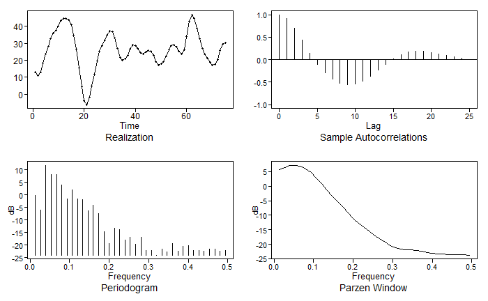

```r
x31 = gen.arma.wge(n = 75, phi = c(2.3, -1.92, .56), theta = -.8, sn=61, plot = FALSE)
x31 = x31 + 30
plotts.sample.wge(x31)
```

```r
aic5.wge(x31, p=0:8, q=0:2)
```

```
---------WORKING... PLEASE WAIT...


Five Smallest Values of  aic
```

|  | p | q | aic |
| --- | --- | --- | --- |
| 20 | 6 | 1 | 0.04601791 |
| 23 | 7 | 1 | 0.05788330 |
| 11 | 3 | 1 | 0.06646122 |
| 26 | 8 | 1 | 0.07820027 |
| 14 | 4 | 1 | 0.08249288 |

```r
# picks ARMA(6,1)
est.arma.wge(x31, p=6, q=1)
```

```
Coefficients of Original polynomial:
2.1358 -1.8220 0.8034 -0.5187 0.5518 -0.2954

Factor                 Roots                Abs Recip    System Freq
1-1.7790B+0.8890B^2    1.0006+-0.3518i      0.9429       0.0538
1-1.1361B+0.7250B^2    0.7835+-0.8749i      0.8515       0.1338
1+0.7792B+0.4583B^2   -0.8500+-1.2080i      0.6770       0.3476


$phi
[1]  2.1358460 -1.8220299  0.8034331 -0.5186502  0.5518156 -0.2954084

$theta
[1] -0.8267488

$res
 [1] -0.305164591  0.017704810  0.898551965  0.290259826 -0.731963373  0.750020008  1.259726047 -0.729729215
 [9]  0.480530491  2.194199879 -0.240670627  0.573146921  1.198125424  0.892074397 -0.431953345 -0.503774571
[17] -0.732902896 -2.342897279  0.005506602 -1.507182928  1.625050118 -0.578650288 -1.001710927  0.532685070
[25]  0.054300563 -0.721719478 -0.717234137  0.504241023 -0.400146585  0.507805977 -2.257608715  0.258733596
[33] -1.349731844  1.554973484  0.419098305 -0.543314447  0.796823896  1.077481156 -0.635937878 -0.325714340
[41] -0.425189307  0.355557665  0.299092826  0.004072099 -0.763363714 -0.264270825 -0.980338636 -0.385770613
[49]  1.135229604 -0.911030905 -0.138124500  0.722178465  0.119015565 -0.283157134 -0.616883661 -0.342792906
[57] -0.454341621  0.349196790  2.871086097  1.199248591  0.613028038 -1.317260148  0.429244604  1.204719073
[65] -0.960964543  0.440333486 -0.150725023 -0.352381288  0.020119919  0.532503360  0.463208786  1.656279667
[73] -0.248959886 -0.886049941 -0.408010146

$avar
[1] 0.8459327

$aic
[1] 0.04601791

$aicc
[1] 1.109608

$bic
[1] 0.2932166

$se.phi
[1] 0.03408636 0.27539709 0.53907608 0.45429397 0.18305048 0.02103705

$se.theta
[1] 0.03902739
```

```r
# type BIC
aic5.wge(x31, p=0:8, q=0:2, type="bic")
```

```
---------WORKING... PLEASE WAIT...


Five Smallest Values of  bic
```

|  | p | q | bic |
| --- | --- | --- | --- |
| 11 | 3 | 1 | 0.2209604 |
| 9 | 2 | 2 | 0.2613963 |
| 14 | 4 | 1 | 0.2678919 |
| 20 | 6 | 1 | 0.2932166 |
| 17 | 5 | 1 | 0.2990913 |

```r
# BIC picks ARMA(3,1)
est.arma.wge(x31, p=3, q=1)
```

```
Coefficients of Original polynomial:
2.0570 -1.5284 0.3760

Factor                 Roots                Abs Recip    System Freq
1-1.5523B+0.7449B^2    1.0419+-0.5068i      0.8631       0.0720
1-0.5047B              1.9813               0.5047       0.0000


$phi
[1]  2.0569934 -1.5283557  0.3759623

$theta
[1] -0.9392223

$res
 [1] -0.39793942  0.10827718  1.04486811  0.24852815 -0.82286995  0.60407309  1.19053486 -0.65786732  0.97280047
[10]  2.43072333 -0.30956784  0.62298406  1.09916458  0.29420793 -0.68002291 -0.59941102 -1.17258204 -2.54596363
[19] -0.08623723 -1.53625199  1.53510298 -0.57404617 -1.19907187  0.23132693  0.08013465 -0.71710411  0.34041369
[28]  1.01936820  0.30495995  0.96460064 -1.87035630  0.17977278 -1.29605885  1.56946778  0.55257913 -0.42676611
[37]  0.38026087  0.79977426 -1.40366092 -0.08610595 -0.54381463  0.60799967  0.47282420  0.43170414 -0.98914682
[46] -0.22580529 -1.40362701 -0.21734320  1.19926982 -0.51205969 -0.13136482  0.91843806 -0.34867418 -0.22462088
[55] -0.50838416 -0.22571573 -0.28446263  0.75286005  2.99368127  1.24985792  0.32452085 -1.68771372 -0.22400004
[64]  0.93699007 -0.64880769  0.87557726  0.05020531 -0.91959124 -0.39106768  0.05065239  0.02613392  1.67912626
[73] -0.31538072 -0.94382617 -0.48333705

$avar
[1] 0.9353148

$aic
[1] 0.06646122

$aicc
[1] 1.109598

$bic
[1] 0.2209604

$se.phi
[1] 0.01176724 0.03823560 0.01188732

$se.theta
[1] 0.002444092
```

```r
mean(x31)
```

```
[1] 25.73985
```

```r
# mean is 25.73985
```

### 9.10.5

Because the AIC favored the AR(4,1) and the BIC favored the AR(2,1), which one should we pick?

*We should look at the ACF and spectral density to gather more information about the characteristics and features of the data. In addition we should look at the factor table for each model to help match the model with those characteristics. We will also need to use our intuition and any domain knowledge we may have to choose a model that makes the most sense and will be the most useful (because both of them are likely not the “correct” model).*

```r
df_inflation = read.csv("./inflation.csv")
# type AIC
aic5.wge(df_inflation$Inflation, p=0:8, q=0:2, type="aic")
```

```
---------WORKING... PLEASE WAIT...


Five Smallest Values of  aic
```

|  | p | q | aic |
| --- | --- | --- | --- |
| 14 | 4 | 1 | 2.109741 |
| 8 | 2 | 1 | 2.110736 |
| 24 | 7 | 2 | 2.111421 |
| 18 | 5 | 2 | 2.111800 |
| 17 | 5 | 1 | 2.112308 |

```r
# AIC picks ARMA(4,1)
# est.arma.wge(df_inflation$Inflation, p=4, q=1)
# mean(df_inflation$Inflation)
# mean is 25.73985


aic5.wge(df_inflation$Inflation, p=0:8, q=0:2, type="bic")
```

```
---------WORKING... PLEASE WAIT...


Five Smallest Values of  bic
```

|  | p | q | bic |
| --- | --- | --- | --- |
| 8 | 2 | 1 | 2.134678 |
| 6 | 1 | 2 | 2.137678 |
| 9 | 2 | 2 | 2.142690 |
| 11 | 3 | 1 | 2.142817 |
| 14 | 4 | 1 | 2.145654 |

## 9.11 Model Identification: Box–Jenkins, Part I

### 9.11.4

Box-Jenkins Model Identification for MA(q) and AR(p) models

MA(q) - look at the sample auto-correlation plot (ACF)

p_k = 0; for k > q

AR(p) - look at the sample partial auto-correlation plot (PACF)

phi_kk = 0; for k > p

## 9.12 Model Identification: Box–Jenkins, Part II

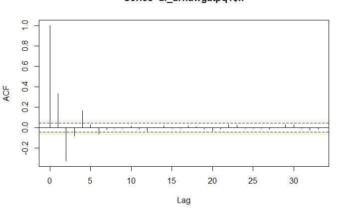

```r
df_arnawgatpq1 = read.csv("./armawhatpq1.csv")

acf(df_arnawgatpq1$x)
```

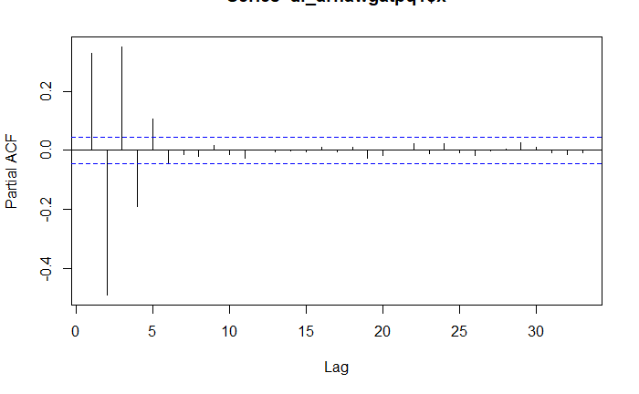

```r
pacf(df_arnawgatpq1$x)
```

```r
# type AIC
aic5.wge(df_arnawgatpq1$x, p=0:8, q=0:2, type="aic")
```

```
---------WORKING... PLEASE WAIT...


Five Smallest Values of  aic
```

|  | p | q | aic |
| --- | --- | --- | --- |
| 9 | 2 | 2 | -0.03227869 |
| 11 | 3 | 1 | -0.03216856 |
| 14 | 4 | 1 | -0.03150759 |
| 12 | 3 | 2 | -0.03148804 |
| 19 | 6 | 0 | -0.03125914 |

```r
# AIC picks ARMA(2,2)

# type BIC
aic5.wge(df_arnawgatpq1$x, p=0:8, q=0:2, type="bic")
```

```
---------WORKING... PLEASE WAIT...


Five Smallest Values of  bic
```

|  | p | q | bic |
| --- | --- | --- | --- |
| 9 | 2 | 2 | -0.01827643 |
| 11 | 3 | 1 | -0.01816630 |
| 14 | 4 | 1 | -0.01470489 |
| 12 | 3 | 2 | -0.01468533 |
| 16 | 5 | 0 | -0.01357632 |

```r
# BIC picks ARMA(2,2)
```

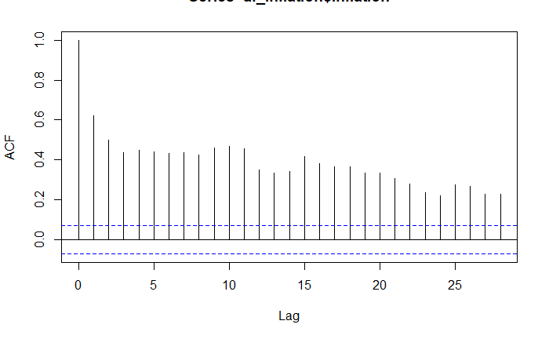

```r
acf(df_inflation$Inflation)
```

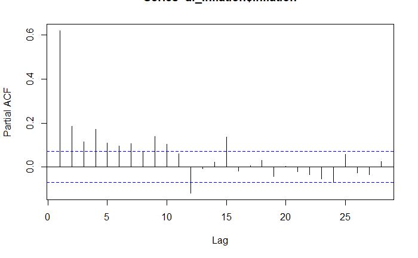

```r
pacf(df_inflation$Inflation)
```

## 9.13 Putting It All Together: Model ID, Estimation, Forecasting

```
$autplt
 [1] 1.0000000 0.9812607 0.9485558 0.9096771 0.8684132 0.8251700 0.7835162 0.7453261 0.7096470 0.6747143 0.6382594
[12] 0.6001387 0.5635623 0.5260189 0.4881868 0.4523773 0.4200285 0.3895181 0.3575383 0.3263927 0.2975097 0.2695047
[23] 0.2400592 0.2096427 0.1815298 0.1561659

$freq
  [1] 0.004878049 0.009756098 0.014634146 0.019512195 0.024390244 0.029268293 0.034146341 0.039024390 0.043902439
 [10] 0.048780488 0.053658537 0.058536585 0.063414634 0.068292683 0.073170732 0.078048780 0.082926829 0.087804878
 [19] 0.092682927 0.097560976 0.102439024 0.107317073 0.112195122 0.117073171 0.121951220 0.126829268 0.131707317
 [28] 0.136585366 0.141463415 0.146341463 0.151219512 0.156097561 0.160975610 0.165853659 0.170731707 0.175609756
 [37] 0.180487805 0.185365854 0.190243902 0.195121951 0.200000000 0.204878049 0.209756098 0.214634146 0.219512195
 [46] 0.224390244 0.229268293 0.234146341 0.239024390 0.243902439 0.248780488 0.253658537 0.258536585 0.263414634
 [55] 0.268292683 0.273170732 0.278048780 0.282926829 0.287804878 0.292682927 0.297560976 0.302439024 0.307317073
 [64] 0.312195122 0.317073171 0.321951220 0.326829268 0.331707317 0.336585366 0.341463415 0.346341463 0.351219512
 [73] 0.356097561 0.360975610 0.365853659 0.370731707 0.375609756 0.380487805 0.385365854 0.390243902 0.395121951
```

[output cut: 31 more lines]

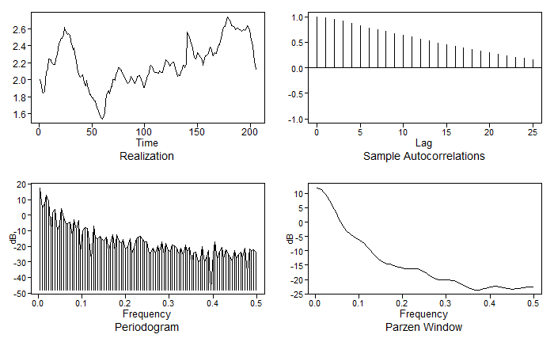

```r
df_texasgasprice = read.csv("./texasgasprice.csv")

# head(df_texasgasprice)

plotts.sample.wge(df_texasgasprice$Price)
```

```r
aic5.wge(df_texasgasprice$Price, type = "aic")
```

```
---------WORKING... PLEASE WAIT...


Five Smallest Values of  aic
```

|  | p | q | aic |
| --- | --- | --- | --- |
| 7 | 2 | 0 | -6.131525 |
| 8 | 2 | 1 | -6.124641 |
| 10 | 3 | 0 | -6.123937 |
| 9 | 2 | 2 | -6.116413 |
| 13 | 4 | 0 | -6.116182 |

```r
# picks AR(2)

aic5.wge(df_texasgasprice$Price, type = "bic")
```

```
---------WORKING... PLEASE WAIT...


Five Smallest Values of  bic
```

|  | p | q | bic |
| --- | --- | --- | --- |
| 7 | 2 | 0 | -6.082895 |
| 8 | 2 | 1 | -6.059802 |
| 10 | 3 | 0 | -6.059098 |
| 5 | 1 | 1 | -6.049422 |
| 6 | 1 | 2 | -6.049014 |

```r
# picks AR(2)
```

```r
est = est.ar.wge(df_texasgasprice$Price, p=2, type = "mle")
```

```
Coefficients of Original polynomial:
1.3812 -0.4077

Factor                 Roots                Abs Recip    System Freq
1-0.9536B              1.0487               0.9536       0.0000
1-0.4276B              2.3386               0.4276       0.0000



Coefficients of Original polynomial:
1.3812 -0.4077

Factor                 Roots                Abs Recip    System Freq
1-0.9536B              1.0487               0.9536       0.0000
1-0.4276B              2.3386               0.4276       0.0000
```

```r
est
```

```
$phi
[1]  1.3811579 -0.4077432

$res
  [1] -0.0310967793 -0.0630039986 -0.0565786421  0.0171753271  0.0112505642  0.1079432622  0.0410190541  0.0046068868
  [9]  0.0912435510 -0.0432822097 -0.0109961325 -0.0300144940  0.0088142740 -0.0115775325  0.0013122197  0.0741284471
 [17]  0.0256729444  0.0488556669  0.0319550579  0.0257179066  0.0111351474  0.0002560437  0.0504374924  0.0734554439
 [25] -0.0542665512 -0.0106345568  0.0042770318  0.0276557649 -0.0122840927 -0.0443192328 -0.0093813900 -0.0392185046
 [33]  0.0426958180 -0.0605393120 -0.0723691740 -0.0227179698 -0.0270981785 -0.0413735284  0.0102933034  0.0086402925
 [41]  0.0141324393 -0.0525833469 -0.0443666794 -0.0203315613  0.0749376650 -0.0966864146 -0.0409735137 -0.0281995999
 [49]  0.0051067593 -0.0396904664  0.0009022004 -0.0353566800 -0.0182354745 -0.0369493688 -0.0386839484 -0.0428665701
 [57] -0.0286164463 -0.0207678348 -0.0459547732 -0.0081913064  0.0020091440  0.0270829999  0.1065755786 -0.0021351058
 [65]  0.0082534275 -0.0165533023 -0.0499898538  0.0835981651 -0.0362186520  0.0744418416 -0.0379710383 -0.0185095130
 [73]  0.0808532834 -0.0123211713  0.0365582349 -0.0203326683 -0.0337344108  0.0158703866 -0.0400831846 -0.0163227828
 [81] -0.0223291145 -0.0023111849 -0.0387319006 -0.0103253305  0.0108035879  0.0152183030  0.0313590429 -0.0353618012
```

[output cut: 27 more lines]

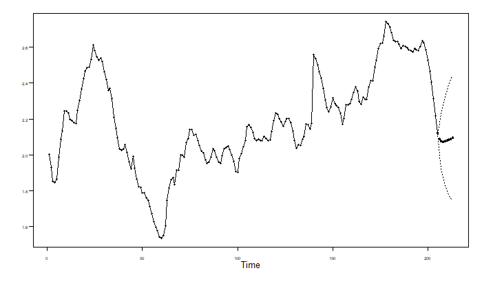

```r
tx_gas_forecast = fore.arma.wge(df_texasgasprice$Price, phi = est$phi, n.ahead = 8, plot = TRUE)
```

```r
tx_gas_forecast$f
```

```
[1] 2.087504 2.075425 2.073623 2.076059 2.080159 2.084828 2.089605 2.094299
```

```r
# 2.087504 (1)
# 2.094299 (8)
```